# Live_Session_Assignment_6

Stuart Miller

6/11/2019

```r
library(dplyr)
library(ggplot2)
```

# Background

We are looking for areas that might need additional VA hospitals offering mental health services in the 48 contiguous states of the United States.

**Disclaimer:** While these are real data, the assignment is not an endorsement for any particular position on medical affairs or building hospitals. It is for instructional use only.

# Question 1

Load the data from [National Mental Health Services Survey (N-MHSS): 2015](https://datafiles.samhsa.gov/study-dataset/national-mental-health-services-survey-2015-n-mhss-2015-ds0001-nid17098), which contains all known healthcare centers offering mental health services in the United States in 2015.

## Part A

Load the healthcare center data set.

```r
# load from National Mental Health Services Survey (N-MHSS): 2015
# data set is loaded under object name mh2015pf
load("./N-MHSS-2015-DS0001-bndl-data-r/N-MHSS-2015-DS0001-data/N-MHSS-2015-DS0001-data-r.rda")
```

## Part B

Get all the state codes in the data.frame.

```r
# get unique state code
states <- unique(as.character(mh2015_puf$LST))
```

## Part C

Remove the codes which do not corresponding to the 48 contiguous states.

```r
remove.states <- c("AS    ", "GU    ", "PR    ", "VI    ", "AK    ", "HI    ")
states.of.interest <- states[! states %in% remove.states]
filtered <- mh2015_puf[which(mh2015_puf$LST %in% states.of.interest),]
filtered <- data.frame(filtered %>% count(LST))
```

## Part D

Plot the number of known healthcare centers offering mental health services in each state of mainland United States.

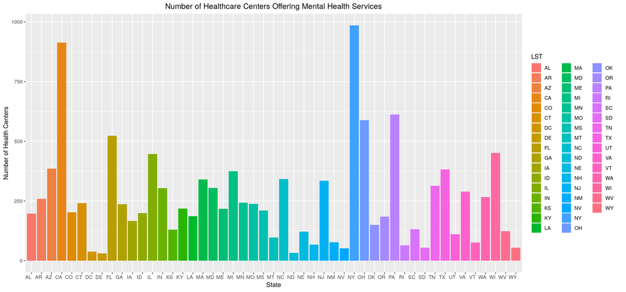

```r
ggplot(filtered, aes(x = LST, y = n, fill = LST)) +
  geom_bar(stat = 'identity') +
  ggtitle("Number of Healthcare Centers Offering Mental Health Services") +
  theme(plot.title = element_text(hjust = 0.5)) +
  xlab('State') +
  ylab('Number of Health Centers')
```

# Question 2

## Part A

Load ‘statesize.csv’, which contains sizes of states. Notice that the dataframes cannot be merged becuase of the extra white space in the abbreviation column of the healthcare center data.

```r
# birng in state sizes
state.sizes <- read.csv("./statesize.csv")

# names values in LST and state.sizes$Abbrev don't match
# because of the white space in LST at the end of the abbreviation
print("Abbreviations from LST")
```

```
## [1] "Abbreviations from LST"
```

```r
print(paste(filtered$LST))
```

```
##  [1] "AL    " "AR    " "AZ    " "CA    " "CO    " "CT    " "DC    "
##  [8] "DE    " "FL    " "GA    " "IA    " "ID    " "IL    " "IN    "
## [15] "KS    " "KY    " "LA    " "MA    " "MD    " "ME    " "MI    "
## [22] "MN    " "MO    " "MS    " "MT    " "NC    " "ND    " "NE    "
## [29] "NH    " "NJ    " "NM    " "NV    " "NY    " "OH    " "OK    "
## [36] "OR    " "PA    " "RI    " "SC    " "SD    " "TN    " "TX    "
## [43] "UT    " "VA    " "VT    " "WA    " "WI    " "WV    " "WY    "
```

```r
print("Abbreviations from state.sizes")
```

```
## [1] "Abbreviations from state.sizes"
```

```r
print(state.sizes$Abbrev)
```

```
##  [1] AL AK AZ AR CA CO CT DE FL GA HI ID IL IN IA KS KY LA ME MD MA MI MN
## [24] MS MO MT NE NV NH NJ NM NY NC ND OH OK OR PA RI SC SD TN TX UT VT VA
## [47] WA WV WI WY
## 50 Levels: AK AL AR AZ CA CO CT DE FL GA HI IA ID IL IN KS KY LA MA ... WY
```

## Part B

Remve the white space from the healthcare center data and merge with the state size data.

```r
# fix remove extra whitespace in LST
filtered$LST <- gsub('\\s+', '', filtered$LST)
# merge filtered and state.sizes
state.sizes$Abbrev <- as.character(state.sizes$Abbrev)
states.hospitals.sizes <- merge(filtered, state.sizes, by.x = 'LST', by.y = 'Abbrev')
```

## Part C

Create a new variable in the merged data set that represents the density of healthcare centers per state (number of healthcare centers per 1000 square miles).

```r
# create new column for hospitals per thousand miles
states.hospitals.sizes$HospDensity <- states.hospitals.sizes$n/states.hospitals.sizes$SqMiles*1000
```

## Part D

Plot the density of healthcare centers per state.

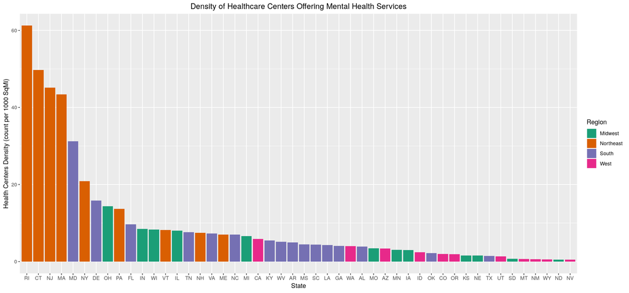

```r
ggplot(states.hospitals.sizes,
       aes(x = reorder(LST, -HospDensity), y = HospDensity, fill = Region)) +
  geom_bar(stat = 'identity') +
  ggtitle("Density of Healthcare Centers Offering Mental Health Services") +
  theme(plot.title = element_text(hjust = 0.5)) +
  xlab('State') +
  ylab('Health Centers Density (count per 1000 SqMi)') +
  scale_fill_brewer(palette="Dark2")
```

## Part E

*Some Observations About The Data*

```r
with(states.hospitals.sizes, tapply(SqMiles, Region, mean))/1000
```

```
##   Midwest Northeast     South      West
##  62.60433  18.03044  54.43812 106.78918
```

- The average area (in 1k square miles) of states increases from east to west.

Because of the differences in sizes of states and various number of population centers within states, it would likely be necessary to look at the density of health centers relative to population centers (cities, metroplexes, etc.) to see the variation that is not obvious at the state level. This mapping would help identify large population areas where there are lower numbers of health centers.